# Spacy for Doc Similarity Analysis

### Steps

#### Note

- Author: Luke Arunanondchai
- Python 3.5
- Last Updated: 4/15/18

#### Steps within the AccountingTokenizer Class

1. Accounting and auditing words are loaded into the word matcher for detecting them in texts. They are not stematized in this step so that their uniqueness is maintained. For example, 'accounts receivable'. If this word is stematized first, it will cause a problem when we try to identify a two-word phrase, because we will have account and receiv separately. Thus, the dictionay will not be able to match it.
2. Accounting and auditing words with s,es,ed are loaded into the word matcher.
3. Texts are tokenized.
4. The tokenized texts are then matched with the word list stored in the word matcher to find all the accounting words and their locations in the texts.
5. The tokenized texts are stemmatized.
6. The matched accounting and auditing words are stemmatized.
7. The stemmatized tokens of the text are replaced with accounting and auditing tokens corresponding to their detected locations. Partial tokens from multi-word phrases are then dropped.

#### Step within the replaceMatch Function

1. Next, I deal with synonyms and acronyms with s,es,and ed by stemmatized them and match them back to the outcome from step 7.

These steps produced the final output of stmmatized tokens of texts.

```python
import re
import nltk
import difflib
import gensim
import sklearn
import warnings
import operator
warnings.filterwarnings(action='ignore', category=UserWarning, module='gensim')

import matplotlib.pyplot as plt
from matplotlib import colors
from matplotlib.ticker import PercentFormatter

from gensim import corpora
from sklearn.feature_extraction.text import TfidfVectorizer, CountVectorizer
from sklearn.metrics.pairwise import cosine_similarity

import spacy, time, pandas as pd, numpy as np, string
from spacy.tokenizer import Tokenizer
from nltk.corpus import stopwords
from spacy.matcher import PhraseMatcher
from flashtext import KeywordProcessor

pd.set_option('display.max_colwidth', 100)

ps = nltk.PorterStemmer()
wn = nltk.WordNetLemmatizer()
stopwords = list(set(nltk.corpus.stopwords.words('english')))
```

```python
# Importing KAM data and considering ONLY KAMs that have all text requirements (description, address, reference)
xl1 = pd.ExcelFile('..\\input\\KAM parsed w report stats categories.xlsx')
data = xl1.parse('Sheet1',header=0)
data[sorted(data.columns)]
data.columns = [x.lower() for x in data.columns]
```

```python
item_name = ['cam_description', 'how_addressed','reference']
for x in item_name:
    data[x] = data[x].replace('\n',' ')

df_description = data.dropna(subset=['cam_description'])
df_address = data.dropna(subset=['how_addressed'])
df_reference = data.dropna(subset=['reference'])

data = data.dropna(subset=['cam_description', 'how_addressed','reference'])
data['full_kam'] = data['cam_description']+ ' ' + data['how_addressed'] + ' ' + data['reference']
```

```python
def clean_text_traditional(text):
    """ Converting all to lower case, splitting words, dropping punctuations, grouping,
    tokenizing (unigram) and porter stemming text
    """
    text = "".join([word.lower() for word in text if word not in string.punctuation])
    text = re.split('\W+', text)
    text = [ps.stem(word) for word in text if word not in stopwords]

    return text

def clean_text(text):
    """ Converting all to lower case, splitting words, dropping punctuations, grouping,
    tokenizing (by dictionary-matching) and porter stemming text
    """
    text = "".join([word.lower() for word in text if word not in string.punctuation])
    text = re.split('\W+', text)
    text = [t for t in text if not t in string.punctuation]
    text = matching_phrases(text, wordlist)
    text = [ps.stem(word) for word in text if word not in stopwords]

    return text

def doc_feature(i_data):
    i_data['token_full'] =i_data['full_kam'].apply(clean_text)
    i_data['token_description']=i_data['cam_description'].apply(clean_text)
    i_data['token_addressed']=i_data['how_addressed'].apply(clean_text)
    i_data['token_reference']=i_data['reference'].apply(clean_text)

    return i_data
```

```python
def readin_doc(doc):
    return doc

def get_cosine_sim(tokenized_column, method):
    if method == 'traditional':
        print('Calculating traditional cosine ...')
        tfidf_vect = TfidfVectorizer(analyzer=clean_text_traditional)
    else:
        print('Calculating cosine with word-list application ...')
        tfidf = TfidfVectorizer(token_pattern=r'(\w[^\'|\"|\,|\(|\)|\/|\\]+)', analyzer='word')
    X_tfidf = tfidf.fit_transform(tokenized_column)
    X_tfidf_feat = pd.DataFrame(X_tfidf.toarray())
    X_tfidf_feat.columns = tfidf.get_feature_names()

    cosine = sklearn.metrics.pairwise.cosine_similarity(X=X_tfidf_feat,
                                                        Y=X_tfidf_feat,
                                                        dense_output=True)

    return cosine
```

## Function breakdown

```python
# Function breakdown
wordlist   = pd.read_excel("..\\input\\combined_wordlist.xlsx",sheet_name="Sheet1")

nlp        = spacy.load('en_core_web_sm')
unwanted   = stopwords + list(string.punctuation)+['\n','–','’s','•','••']
matcher    = PhraseMatcher(nlp.vocab)
accounting = list(wordlist.Word)+list(map(lambda x:x+'s',wordlist.Word))+list(map(lambda x:x+'es',wordlist.Word))+list(map(lambda x:x+'ed',wordlist.Word))
# accounting = list(map(ps.stem,accounting))
patterns   = list(nlp.pipe(accounting))
# Add accounting and auditing words
matcher.add('ACC', None, *patterns)
accMatch   = []
```

## Test

```python
# text = 'I have an accounts receivable and accounts receivables.'
text = 'I have an abc method and abc methods and accounts receivable and accounts receivables.'
# text = 'I have an abc method and abc methods and abc methoded.'

doc             = nlp(text.lower().lstrip())          # Remove leading space
token           = [ps.stem(t.text) for t in doc]      # Tokenizing
matches         = matcher(doc)                        # Apply our matcher to text

# Check which accounting or auditing words are matched and keep only stems
accMatch   = [ps.stem(str(doc[start:end])) for match_id, start, end in matches]
# Create indices for accounting or auditing words for cleaning purpose
m_ind           = [(start,end) for match_id, start, end in matches]
ll = []
# Remove unused partial words and replace them with full stem words
for i in m_ind:
    ll = ll + list(range(i[0]+1,i[1]))
for i in range(len(accMatch)):
    token[m_ind[i][0]] = accMatch[i]
matched         = [i for j, i in enumerate(token) if j not in ll]
[w for w in matched if w not in unwanted]
```

```
['abc method', 'abc method', 'accounts receiv', 'accounts receiv']
```

```python
doc
```

```
i have an abc method and abc methods and accounts receivable and accounts receivables.
```

This chunk of codes tokenizes the text and take care of accounting more-than-one-word phrases, synonym, and acronym as well

```python
# =Luke===================================================================
# Spacy Model: Create tools to deal with auditing and accounting words
# ========================================================================

# Load a spacy model
nlp        = spacy.load('en_core_web_sm')

# Import our wordlist
wordlist   = pd.read_excel("..\\input\\combined_wordlist.xlsx",sheet_name="Sheet1")
# Select only the original word column
# accounting = list(wordlist.Word)
accounting = list(wordlist.Word)+list(map(lambda x:x+'s',wordlist.Word))+list(map(lambda x:x+'es',wordlist.Word))+list(map(lambda x:x+'ed',wordlist.Word))

# Create a list of stopwords + punctuation + special characters in texts
unwanted   = stopwords + list(string.punctuation)+['\n','–','’s','•','••','€','£','\n ','\n  ','\n\n',"'s",'’']


class AccountingTokenizer:

    def __init__(self,nlp,accounting):
        self.nlp        = nlp

        # Prepare a matcher for adding accounting and auditing words
        self.matcher    = PhraseMatcher(nlp.vocab)
        self.accounting = accounting
        self.patterns   = list(nlp.pipe(self.accounting))

        # Add accounting and auditing words
        self.matcher.add('ACC', None, *self.patterns)
        self.accMatch   = []

    def tokenizeIt(self,text):
        doc             = nlp(text.lower().lstrip())          # Remove leading space
        token           = [ps.stem(t.text) for t in doc]      # Tokenizing
        matches         = self.matcher(doc)                   # Apply our matcher to text

        # Check which accounting or auditing words are matched and keep only stems
        self.accMatch   = [ps.stem(str(doc[start:end])) for match_id, start, end in matches]

        # Create indices for accounting or auditing words for cleaning purpose
        m_ind           = [(start,end) for match_id, start, end in matches]
        ll = []

        # Remove unused partial words and replace them with full stem words
        for i in m_ind:
            ll = ll + list(range(i[0]+1,i[1]))
        for i in range(len(self.accMatch)):
            token[m_ind[i][0]] = self.accMatch[i]
        matched         = [i for j, i in enumerate(token) if j not in ll]

        return [w for w in matched if w not in unwanted]


def replaceMatch(wordlist,raw_tokens):

    # Main Wordlist: for speeding purpose, go through the rows with either an acronym or synonym only
    wordlist2 = wordlist[pd.notnull(wordlist.Acronym) |pd.notnull(wordlist.Synonym)].copy()

    # Prepare the dictionary for matching
    keyword_dict = {}
    for i in wordlist2.index:
        ''' Start mapping the stems of acronyms and synonyms to the stems of their original words
            By doing this, my argument is, it will take care of s, es, and ed forms of the acronyms
            synonyms at the same time. In effect, we don't need to increase workloads to the computer from
            expanding our mapping list to cover words with s,es, and ed, since the stems of those words with
            s,es, and ed should be the same as the stems of the acronyms and synonyms.'''

        keyword_dict.update({ps.stem(wordlist.loc[i,'Word']):[ps.stem(str(wordlist.loc[i,'Acronym'])),
                                                              ps.stem(str(wordlist.loc[i,'Synonym']))]})
    # Clean up the dictionary for mapping by removing nan
    keyword_dict = {k:[elem for elem in v if elem is not np.nan] for k,v in keyword_dict.items()}

    # Build our Keyword Processor by adding the word list of acronyms and synonyms above into it
    myKeys = KeywordProcessor()
    myKeys.add_keywords_from_dict(keyword_dict)


    return [myKeys.replace_keywords(t) for t in raw_tokens]
```

```python
# Instantiate the class objext
s = time.time()
model  = AccountingTokenizer(nlp,accounting)
print("Running time              : ",time.time()-s, "seconds")
```

```
Running time              :  37.499757051467896 seconds
```

My functions do the following things:

1) Matching synonyms and acronyms back to their original words. For example, abc method is matched to activity based costing method.

2) Take care of multiple-word phrases. Ex. when we tokenize accounts receivable, we want to have 'accounts receiv' not 'account' and 'receiv' separately.

3) Tokenization

4) Extract stems of all tokens. Ex accounts receivable => account receiv

## Example 1

My functions

```python
testdat = 'I have an abc method and abc methods and abc methodes and abc methoded.'
replaceMatch(wordlist,model.tokenizeIt(testdat))
```

```
['activity based costing  method',
 'activity based costing  method',
 'activity based costing  method',
 'activity based costing  method']
```

## Example 2

```python
testdat = 'I have a financial statement and an accounts receivable and accounts receivables and account receivable'
replaceMatch(wordlist,model.tokenizeIt(testdat))
```

```
['financial stat', 'accounts receiv', 'accounts receiv', 'account', 'receiv']
```

## Example 3

```python
testdat = 'accredited tax preparer and period end are synonyms.'
replaceMatch(wordlist,model.tokenizeIt(testdat))
```

```
['accredit', 'tax', 'prepar', 'period', 'end', 'synonym']
```

## Example 4

```python
testdat = 'Accounts receivables are added into financial statements and a financial statement. Age analysis is not included.'
replaceMatch(wordlist,model.tokenizeIt(testdat))
```

```
['accounts receiv',
 'ad',
 'financial stat',
 'financial stat',
 'age analysi',
 'includ']
```

## Example 5

```python
testdat = 'i have a sampling and documentary and first in, first out'
replaceMatch(wordlist,model.tokenizeIt(testdat))
```

```
['audit sampling ', 'document', 'fifo  ']
```

## Set up the functions

The time reduced significantly from 11 hours to about 5 miniutes!! :)

```python
# take care of accounting more-than-one-word phrases, synonym, and acronym
s = time.time()
data['token_full'] = data.full_kam.apply(lambda x: model.tokenizeIt(x))
data['token_full'] = data.token_full.apply(lambda x: str(replaceMatch(wordlist,x)))
print("Running time              : ",time.time()-s, "seconds")

s = time.time()
data['token_description'] = data.cam_description.apply(lambda x: model.tokenizeIt(x))
data['token_description'] = data.token_description.apply(lambda x: str(replaceMatch(wordlist,x)))
data['token_addressed'] = data.how_addressed.apply(lambda x: model.tokenizeIt(x))
data['token_addressed'] = data.token_addressed.apply(lambda x: str(replaceMatch(wordlist,x)))
data['token_reference'] = data.reference.apply(lambda x: model.tokenizeIt(x))
data['token_reference'] = data.token_reference.apply(lambda x: str(replaceMatch(wordlist,x)))
print("Running time              : ",time.time()-s, "seconds")
```

```
Running time              :  107.25317335128784 seconds
Running time              :  180.27808094024658 seconds
```

```python
# Slicing the main data into multiple dataframes by audit firms (string), year (int), and
def create_dict_from_df(category, data):
    UniqueNames = data[category].unique()
    df_dict = {elem : pd.DataFrame for elem in UniqueNames}
    for key in df_dict.keys():
        df_dict[key] = data[:][data[category] == key].reset_index(drop=True)
    return df_dict

lst = ['auditor','year','kam_categories']
DataFrameDict = {}
for x in lst:
    DataFrameDict = {**DataFrameDict, **create_dict_from_df(x, data)}

# Merging KPMG AUDIT PLC and KPMG LLP together as KPMG LLP
frames = [DataFrameDict['KPMG AUDIT PLC'],DataFrameDict['KPMG LLP'] ]
DataFrameDict['KPMG LLP'] = pd.concat(frames)
```

```python
dflist= ['KPMG LLP','PRICEWATERHOUSECOOPERS LLP','ERNST & YOUNG LLP','DELOITTE LLP',
       2013,2014,2015,'goodwill impairment/intangible assets']

for i in dflist:
    DataFrameDict[i]['token_full'] = DataFrameDict[i]['token_full'].str.lower().str.replace('[{}]'.format('\'[\\]'), '').str.split(',').apply(lambda x:str([item.lstrip() for item in x if item not in unwanted]))
```

# Cosine Similarity

```
Calculating cosine with word-list application ...
Calculating cosine with word-list application ...
Calculating cosine with word-list application ...
Calculating cosine with word-list application ...
```

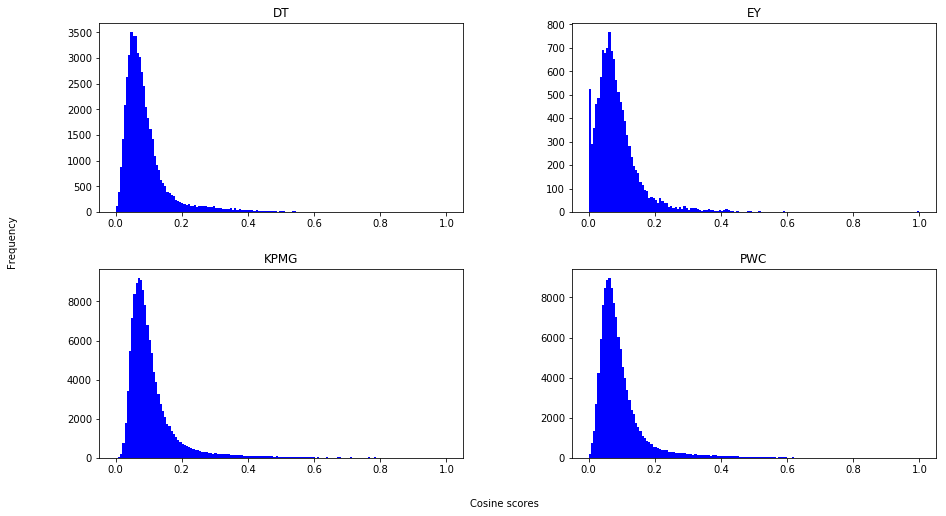

```python
# Cosine similarity of full KAM across firms
cosine_full_kpmg = pd.DataFrame(get_cosine_sim(DataFrameDict['KPMG LLP']['token_full'],'new')).set_index(DataFrameDict['KPMG LLP']['auditor'])
cosine_full_pwc = pd.DataFrame(get_cosine_sim(DataFrameDict['PRICEWATERHOUSECOOPERS LLP']['token_full'],'new')).set_index(DataFrameDict['PRICEWATERHOUSECOOPERS LLP']['auditor'])
cosine_full_ey = pd.DataFrame(get_cosine_sim(DataFrameDict['ERNST & YOUNG LLP']['token_full'],'new')).set_index(DataFrameDict['ERNST & YOUNG LLP']['auditor'])
cosine_full_dt = pd.DataFrame(get_cosine_sim(DataFrameDict['DELOITTE LLP']['token_full'],'new')).set_index(DataFrameDict['DELOITTE LLP']['auditor'])

ut_kpmg = cosine_full_kpmg.mask(np.triu(np.ones(cosine_full_kpmg.shape)).astype(bool)).stack().reset_index(drop=True)
ut_pwc = cosine_full_pwc.mask(np.triu(np.ones(cosine_full_pwc.shape)).astype(bool)).stack().reset_index(drop=True)
ut_ey = cosine_full_ey.mask(np.triu(np.ones(cosine_full_ey.shape)).astype(bool)).stack().reset_index(drop=True)
ut_dt = cosine_full_dt.mask(np.triu(np.ones(cosine_full_dt.shape)).astype(bool)).stack().reset_index(drop=True)

cosine_full_firm = pd.concat([ut_kpmg,ut_pwc,ut_ey,ut_dt],axis=1)
cosine_full_firm.columns = ['KPMG','PWC','EY','DT']

plt.rcParams["figure.figsize"] = (15, 8)
fig, axes = plt.subplots(nrows=2, ncols=2, sharex='row')
hist_firm = cosine_full_firm.hist(color='blue',bins = 150, ax=axes, grid=False,sharey=False)
#plt.suptitle('Cosine Similarity Scores of KAMs by Firms in 2013-2015')
fig.text(0.5, 0.04, 'Cosine scores', ha='center')
fig.text(0.04, 0.5, 'Frequency', va='center', rotation='vertical')
#plt.savefig('cosine_full_firm.png')
```

```
Calculating cosine with word-list application ...
Calculating cosine with word-list application ...
Calculating cosine with word-list application ...
```

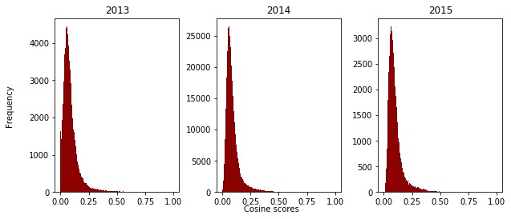

```python
# Cosine similarity of full KAM across years
cosine_full_13 = pd.DataFrame(get_cosine_sim(DataFrameDict[2013]['token_full'],'new')).set_index(DataFrameDict[2013]['year'])
cosine_full_14 = pd.DataFrame(get_cosine_sim(DataFrameDict[2014]['token_full'],'new')).set_index(DataFrameDict[2014]['year'])
cosine_full_15 = pd.DataFrame(get_cosine_sim(DataFrameDict[2015]['token_full'],'new')).set_index(DataFrameDict[2015]['year'])

ut_13 = cosine_full_13.mask(np.triu(np.ones(cosine_full_13.shape)).astype(bool)).stack().reset_index(drop=True)
ut_14 = cosine_full_14.mask(np.triu(np.ones(cosine_full_14.shape)).astype(bool)).stack().reset_index(drop=True)
ut_15 = cosine_full_15.mask(np.triu(np.ones(cosine_full_15.shape)).astype(bool)).stack().reset_index(drop=True)

cosine_full_yr = pd.concat([ut_13,ut_14,ut_15],axis=1)
cosine_full_yr.columns = ['2013','2014','2015']
plt.rcParams["figure.figsize"] = (10, 4)

fig, axes = plt.subplots(nrows=1, ncols=3, sharex='row')

hist_yr = cosine_full_yr.hist(color='darkred',bins = 150, ax=axes, grid=False)
#plt.suptitle('Cosine Similarity Scores of KAMs by Years')
fig.text(0.5, 0.04, 'Cosine scores', ha='center')
fig.text(0.04, 0.5, 'Frequency', va='center', rotation='vertical')
# plt.savefig('cosine_full_year.png')
```

```
Calculating cosine with word-list application ...
```

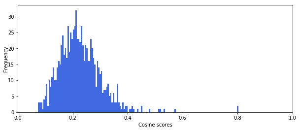

```python
# Cosine similarity of full goodwill KAMs
cosine_full_gw = pd.DataFrame(get_cosine_sim(DataFrameDict['goodwill impairment/intangible assets']['token_full'],'new')).set_index(DataFrameDict['goodwill impairment/intangible assets']['auditor'])
ut_gw = cosine_full_gw.mask(np.triu(np.ones(cosine_full_gw.shape)).astype(bool)).stack().reset_index(drop=True)
hist_gw = ut_gw.hist(color='royalblue',bins = 150, grid=False)
a = plt.gca()
a.set_xlim(0,1)
#plt.suptitle('Cosine Similarity Scores of KAMs on Goodwill Impairment')
plt.xlabel( 'Cosine scores', ha='center')
plt.ylabel('Frequency', va='center', rotation='vertical')
# plt.savefig('cosine_full_goodwill.png')
plt.rcParams["figure.figsize"] = (10, 4)
```

```
Calculating cosine with word-list application ...
```

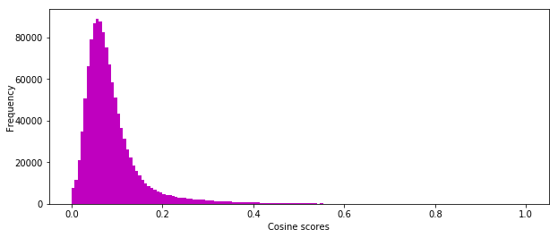

```python
# Cosine similarity of full KAMs
cosine_full = pd.DataFrame(get_cosine_sim(data['token_full'],'new')).set_index(data['auditor'])
ut_full = cosine_full.mask(np.triu(np.ones(cosine_full.shape)).astype(bool)).stack().reset_index(drop=True)
hist_full = ut_full.hist(color='m',bins = 150, grid=False)
#plt.suptitle('Cosine Similarity Scores of KAMs (2013-2015)')
plt.xlabel( 'Cosine scores', ha='center')
plt.ylabel('Frequency', va='center', rotation='vertical')
# plt.savefig('cosine_full_v1.png')
plt.rcParams["figure.figsize"] = (10, 4)
```

```
Calculating cosine with word-list application ...
Calculating cosine with word-list application ...
Calculating cosine with word-list application ...
```

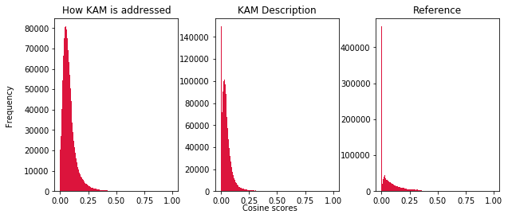

```python
# Cosine similairyt of KAMs by requirements across years
cosine_description = pd.DataFrame(get_cosine_sim(data['token_description'],'new')).set_index(data['auditor'])
cosine_address = pd.DataFrame(get_cosine_sim(data['token_addressed'],'new')).set_index(data['auditor'])
cosine_reference = pd.DataFrame(get_cosine_sim(data['token_reference'],'new')).set_index(data['auditor'])

ut_description = cosine_description.mask(np.triu(np.ones(cosine_description.shape)).astype(bool)).stack().reset_index(drop=True)
ut_address = cosine_address.mask(np.triu(np.ones(cosine_address.shape)).astype(bool)).stack().reset_index(drop=True)
ut_reference = cosine_reference.mask(np.triu(np.ones(cosine_reference.shape)).astype(bool)).stack().reset_index(drop=True)

cosine_item = pd.concat([ut_description,ut_address,ut_reference],axis=1)
cosine_item.columns = ['KAM Description','How KAM is addressed','Reference']
plt.rcParams["figure.figsize"] = (10, 4)

fig, axes = plt.subplots(nrows=1, ncols=3, sharex='row')

hist_yr = cosine_item.hist(color='crimson',bins = 150, ax=axes, grid=False)
#plt.suptitle('Cosine Similarity Scores of KAMs by Requirements')
fig.text(0.5, 0.04, 'Cosine scores', ha='center')
fig.text(0.04, 0.5, 'Frequency', va='center', rotation='vertical')
#plt.savefig('cosine_item.png')
```

## Checking word frequency

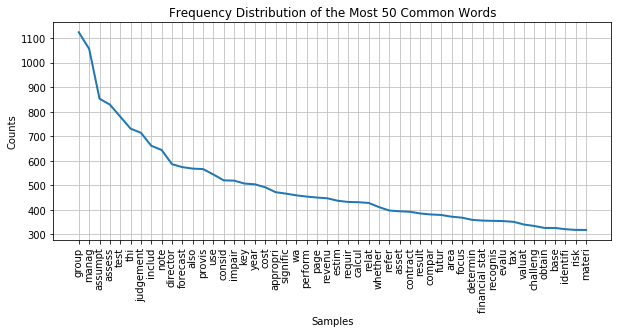

```python
from nltk.tokenize import RegexpTokenizer
import ast
tokenizer = RegexpTokenizer(r'\w+')

wf = data['token_full'].tolist()
audit = (data['auditor']=='PRICEWATERHOUSECOOPERS LLP')
wf = data.loc[audit,'token_full'].tolist()

list1 = ["\'"," ", "\[" , "\]",'€','£','\n ','\n  ','\n\n',"'s",'’']
list2=[]

for i in range(len(wf)):
    a = ast.literal_eval(wf[i])
    list2 = list2+a
list2 = [i for i in list2 if i not in list1]
fd = nltk.probability.FreqDist(list2)
x = wordListToFreqDict(list2)
sorted_all = sorted(x.items(), key=operator.itemgetter(1), reverse=True)
fd.plot(50,cumulative=False,title="Frequency Distribution of the Most 50 Common Words")
```

```python
from nltk.tokenize import RegexpTokenizer
import ast
tokenizer = RegexpTokenizer(r'\w+')
```

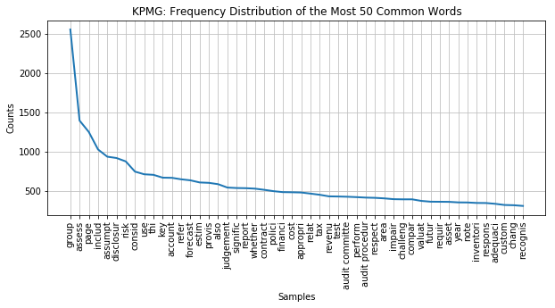

```
KPMG:  506
```

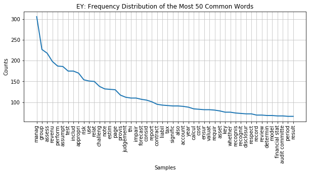

```
EY:  155
```

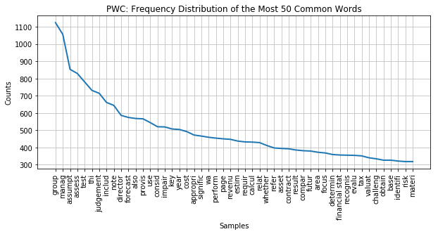

```
PWC:  493
```

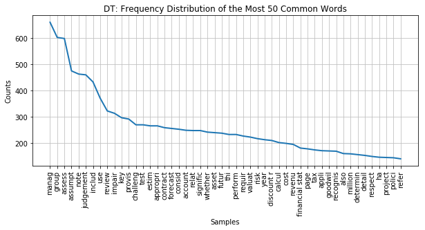

```
DT:  314
```

```python
list1 = ["\'"," ", "\[" , "\]",'€','£','\n ','\n  ','\n\n',"'s",'’']
#KPMG
audit = (data['auditor']=='KPMG LLP')|(data['auditor']=='KPMG AUDIT PLC')
wf = data.loc[audit,'token_full'].tolist()

list2=[]

for i in range(len(wf)):
    a = ast.literal_eval(wf[i])
    list2 = list2+a
list2 = [i for i in list2 if i not in list1]

fd = nltk.probability.FreqDist(list2)
fd.plot(50,cumulative=False,title="KPMG: Frequency Distribution of the Most 50 Common Words")
x = wordListToFreqDict(list2)
sorted_kpmg = sorted(x.items(), key=operator.itemgetter(1), reverse=True)
print('KPMG: ',len(wf))

# ERNST & YOUNG LLP
audit = (data['auditor']=='ERNST & YOUNG LLP')
wf = data.loc[audit,'token_full'].tolist()

list2=[]

for i in range(len(wf)):
    a = ast.literal_eval(wf[i])
    list2 = list2+a
list2 = [i for i in list2 if i not in list1]

fd = nltk.probability.FreqDist(list2)
fd.plot(50,cumulative=False,title="EY: Frequency Distribution of the Most 50 Common Words")
x = wordListToFreqDict(list2)
sorted_ey = sorted(x.items(), key=operator.itemgetter(1), reverse=True)
print('EY: ',len(wf))

# PWC
audit = (data['auditor']=='PRICEWATERHOUSECOOPERS LLP')
wf = data.loc[audit,'token_full'].tolist()

list2=[]

for i in range(len(wf)):
    a = ast.literal_eval(wf[i])
    list2 = list2+a
list2 = [i for i in list2 if i not in list1]

fd = nltk.probability.FreqDist(list2)
fd.plot(50,cumulative=False,title="PWC: Frequency Distribution of the Most 50 Common Words")
x = wordListToFreqDict(list2)
sorted_pwc = sorted(x.items(), key=operator.itemgetter(1), reverse=True)
print('PWC: ',len(wf))

# DT
audit = (data['auditor']=='DELOITTE LLP')
wf = data.loc[audit,'token_full'].tolist()

list2=[]

for i in range(len(wf)):
    a = ast.literal_eval(wf[i])
    list2 = list2+a
list2 = [i for i in list2 if i not in list1]

fd = nltk.probability.FreqDist(list2)
fd.plot(50,cumulative=False,title="DT: Frequency Distribution of the Most 50 Common Words")
x = wordListToFreqDict(list2)
sorted_dt = sorted(x.items(), key=operator.itemgetter(1), reverse=True)
print('DT: ',len(wf))
```

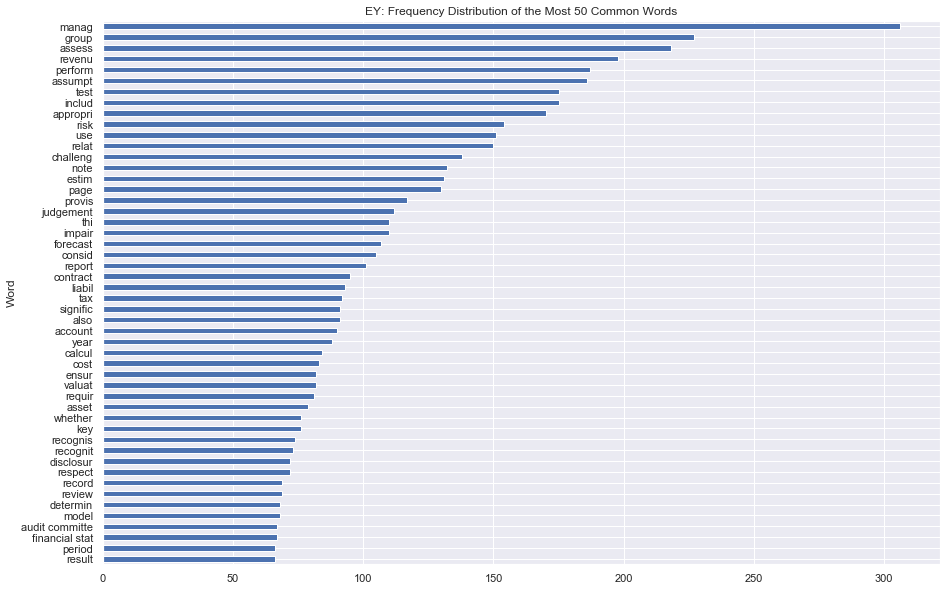

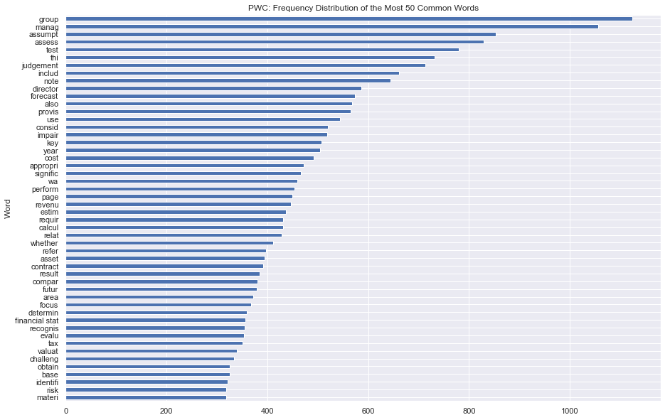

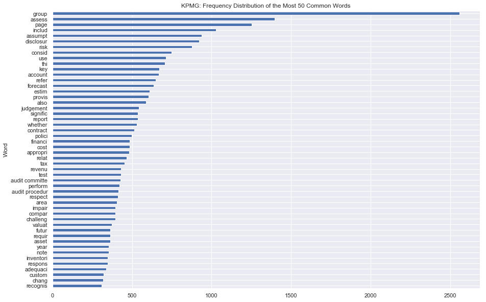

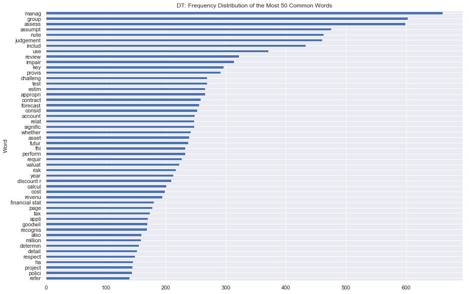

```python
import seaborn as sns
sns.set(style="darkgrid")
df = pd.DataFrame(sorted_ey,columns =['Word','Count'])[0:50].sort_values(by=['Count'])
df.plot.barh(x='Word', y='Count', figsize = (15, 10),legend=False, color='b')
plt.title('EY: Frequency Distribution of the Most 50 Common Words')

df = pd.DataFrame(sorted_pwc,columns =['Word','Count'])[0:50].sort_values(by=['Count'])
df.plot.barh(x='Word', y='Count', figsize = (15, 10),legend=False, color='b')
plt.title('PWC: Frequency Distribution of the Most 50 Common Words')

df = pd.DataFrame(sorted_kpmg,columns =['Word','Count'])[0:50].sort_values(by=['Count'])
df.plot.barh(x='Word', y='Count', figsize = (15, 10),legend=False, color='b')
plt.title('KPMG: Frequency Distribution of the Most 50 Common Words')

df = pd.DataFrame(sorted_dt,columns =['Word','Count'])[0:50].sort_values(by=['Count'])
df.plot.barh(x='Word', y='Count', figsize = (15, 10),legend=False, color='b')
plt.title('DT: Frequency Distribution of the Most 50 Common Words')
```